### ملیکا ادبی نژاد ۸۱۰۱۹۵۵۳۶

## گزارش پروژه ۴

# دسته بندی

```python
import matplotlib.pyplot as plt
import csv
import numpy as np
import pandas
from sklearn.model_selection import train_test_split
from sklearn.metrics import classification_report
from sklearn import metrics

mnist = pandas.read_csv("MNIST/train_data.csv")
labels = pandas.read_csv("MNIST/train_label.csv")

data_eval = pandas.read_csv("MNIST/test_data.csv").values
label_eval = pandas.read_csv("MNIST/test_label.csv").values
```

## (MNIST) بخش اول

#### ۰.پیدا کردن رقم یکان شماره دانشجویی و نمایش آن

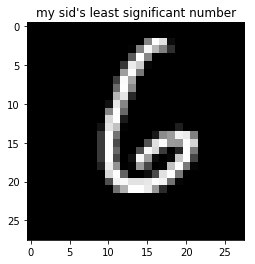

```python
number6 = mnist.loc[[1201]]

pixels = []
for column in number6:
    pixels.append(number6[column].values[0])

pixels = np.array(pixels, dtype='uint8')

# Reshape the array into 28 x 28 array (2-dimensional array)
pixels = pixels.reshape((28, 28))

plt.title('my sid\'s least significant number')
plt.imshow(pixels, cmap='gray')
plt.show()
```

### K-Nearest Neighbors

#### ۱.توضیح الگوریتم

در این الگوریتم هر کدام از داده های یادگیری را به شکل بردارهایی به یک فضا مپ می کنیم. سپس هر داده تست را با تعدادی از همسایه هایش مقایسه میکنیم که این تعداد ثابت است. اکثریت همسایه ها(که درواقع داده های یادگیری هستند که برچسب آن ها را میدانیم) مشخص می کنند که برچسب این داده چیست. پس درواقع اگر نقطه ای در نزدیکی گروهی هست، شانس خوبی وجود دارد که عضو آن گروه باشد.

#### ۲.اجرای الگوریتم

```python
from sklearn.neighbors import KNeighborsClassifier



x_train, x_test, y_train, y_test = train_test_split(mnist, labels, test_size=0.15, random_state=0)

label_test = y_test.values
data_test = x_test.values

features = []
for column in x_train:
    features.append(x_train[column].values)
features_train = list(zip(*features))

label_train = y_train['0'].to_numpy()

model = KNeighborsClassifier(n_neighbors=3)

model.fit(features_train, label_train)



prediction = model.predict(data_eval)
print(classification_report(label_eval, prediction))
print("Accuracy of test:", metrics.accuracy_score(label_eval, prediction))

train_pr = model.predict(data_test)
print("Accuracy of train:", metrics.accuracy_score(label_test, train_pr))
```

[output not shown]

#### ۳.نمودار برای مقادیر مختلف همسایه

```
test max accuracy:  0.9045226130653267  best N:  3  method:  distance
```

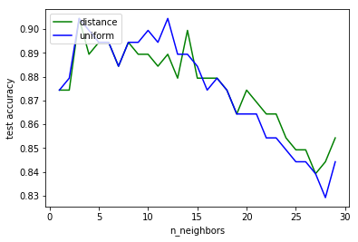

```
train max accuracy:  0.9066666666666666  best N:  1  method:  distance
```

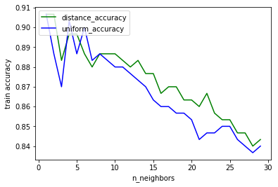

```python
bottom = 1
top = 30

distance_accuracy = []
uniform_accuracy = []

for i in range(bottom, top):
    model = KNeighborsClassifier(n_neighbors=i, weights='distance')
    model.fit(features_train, label_train)
    prediction = model.predict(data_eval)
    distance_accuracy.append(metrics.accuracy_score(label_eval, prediction))

    model = KNeighborsClassifier(n_neighbors=i, weights='uniform')
    model.fit(features_train, label_train)
    prediction = model.predict(data_eval)
    uniform_accuracy.append(metrics.accuracy_score(label_eval, prediction))

x = np.array(range(bottom, top))

max_d = max(distance_accuracy)
max_u = max(uniform_accuracy)

if(max([max_d,max_u])==max(distance_accuracy)):
    max_n = distance_accuracy.index(max(distance_accuracy))+1
    method = "distance"
else:
    max_n = uniform_accuracy.index(max(uniform_accuracy))+1
    method = "uniform"

print("test max accuracy: ", max([max(distance_accuracy),max(uniform_accuracy)]), " best N: ", max_n, " method: " , method)


plt.plot(x, np.array(distance_accuracy), color='g', label='distance')
plt.plot(x, np.array(uniform_accuracy), color='b', label='uniform')
plt.xlabel('n_neighbors')
plt.ylabel('test accuracy')
plt.legend(loc='upper left')
plt.show()



distance_accuracy = []
uniform_accuracy = []

distance_error=[]
uniform_error=[]

for i in range(bottom, top):
    model = KNeighborsClassifier(n_neighbors=i, weights='distance')
    model.fit(features_train, label_train)
    prediction = model.predict(data_test)
    distance_accuracy.append(metrics.accuracy_score(label_test, prediction))
    distance_error.append(metrics.mean_absolute_error(label_test, prediction))

    model = KNeighborsClassifier(n_neighbors=i, weights='uniform')
    model.fit(features_train, label_train)
    prediction = model.predict(data_test)
    uniform_accuracy.append(metrics.accuracy_score(label_test, prediction))
    uniform_error.append(metrics.mean_absolute_error(label_test, prediction))

x = np.array(range(bottom, top))

max_d = max(distance_accuracy)
max_u = max(uniform_accuracy)

if(max([max_d,max_u])==max(distance_accuracy)):
    max_n = distance_accuracy.index(max(distance_accuracy)) + 1
    method = "distance"
else:
    max_n = uniform_accuracy.index(max(uniform_accuracy)) + 1
    method = "uniform"

print("train max accuracy: ", max([max(distance_accuracy),max(uniform_accuracy)]), " best N: ", max_n, " method: " , method)


plt.plot(x, np.array(distance_accuracy), color='g', label='distance_accuracy')
plt.plot(x, np.array(uniform_accuracy), color='b', label='uniform_accuracy')

plt.xlabel('n_neighbors')
plt.ylabel('train accuracy')
plt.legend(loc='upper left')
plt.show()
```

#### ۴.تغییرات خطا

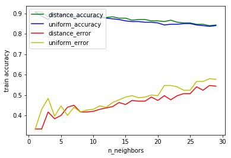

```python
plt.plot(x, np.array(distance_accuracy), color='g', label='distance_accuracy')
plt.plot(x, np.array(uniform_accuracy), color='b', label='uniform_accuracy')
plt.plot(x, np.array(distance_error), color='r', label='distance_error')
plt.plot(x, np.array(uniform_error), color='y', label='uniform_error')

plt.xlabel('n_neighbors')
plt.ylabel('train accuracy')
plt.legend(loc='upper left')
plt.show()
```

#### ۵.نمودار همسایه ها

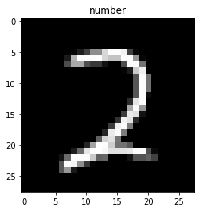

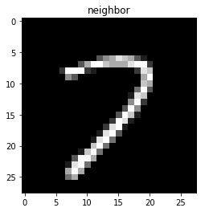

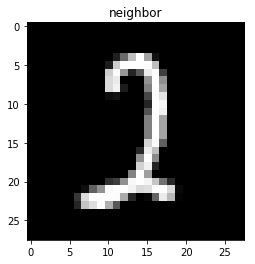

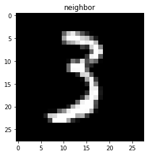

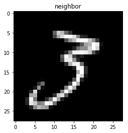

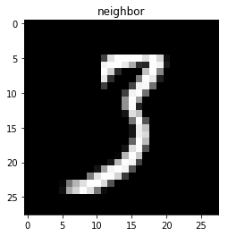

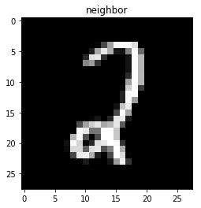

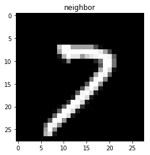

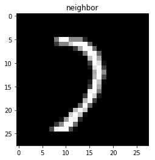

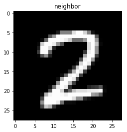

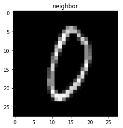

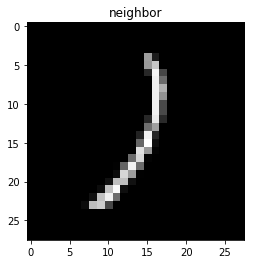

[19 more figures not shown]

```python
model = KNeighborsClassifier(n_neighbors=30, weights='distance')
model.fit(features_train, label_train)
neighbors = model.kneighbors([data_eval[146]])

pixels = np.array(list(data_eval[146]), dtype='uint8')

pixels = pixels.reshape((28, 28))

plt.title('number')
plt.imshow(pixels, cmap='gray')
plt.show()


for n in list(neighbors[1][0]):

    pixels = np.array(features_train[n], dtype='uint8')

    # Reshape the array into 28 x 28 array (2-dimensional array)
    pixels = pixels.reshape((28, 28))

    plt.title('neighbor')
    plt.imshow(pixels, cmap='gray')
    plt.show()
```

#### ۶.مشکلات این الگوریتم

این الگوریتم برای ابعاد بالا مناسب نیست. هرقدر فیچرهای بیشتری داشته باشیم، باید داده های یادگیری را هم بصورت نمایی افزایش دهیم. اما از طرفی بعدهای بالا باعث اورفیت شدن مدل ما می شوند. همچنین در ابعاد بالا فاصله اقلیدسی به خوبی جواب نمی دهد(با توجه به اینکه این الگوریتم با فاصله اقلیدسی کار میکند). تست این مدل از لحاظ زمان و حافظه خیلی هزینه بر است چرا که باید حجم زیاد اطلاعات یادگیری را برای تست نگه داریم. بدلیل مشکلات زیاد بودن بعد ها باید فیچرها کم تر شوند و همچنین فاصله اقلیدسی روی اندازه های بالا خوب کار نمی کند پس اندازه فیچر ها باید نرمال شوند.

### درخت تصمیم(Decision Tree)

#### ۷.توضیح الگوریتم

درخت تصمیم یک ساختار درختی شبیه فلوچارت است که هر گره آن یک تست بر روی فیچر ورودی اجرا میکند و هر شاخه نمایانگر خروجی این تست و هر برگ یک برچسب دسته بندی است. این الگوریتم ورودی ها را با مرتب کردن از بالا تا رسیدن به یک برچسب مرتب می کند.

#### ۸.اجرای الگوریتم

```python
from sklearn.tree import DecisionTreeClassifier

mnist = pandas.read_csv("MNIST/train_data.csv")  # numpy of lists
labels = pandas.read_csv("MNIST/train_label.csv")  # numpy of lists


# Defining and fitting a DecisionTreeClassifier instance
tree = DecisionTreeClassifier(max_depth=350)
tree.fit(mnist, labels)

test_data = pandas.read_csv("MNIST/test_data.csv").values
test_label = pandas.read_csv("MNIST/test_label.csv").values

prediction = tree.predict(test_data)
print(classification_report(test_label, prediction))
print("Accuracy of test:", metrics.accuracy_score(test_label, prediction))

train_p = tree.predict(mnist.values)
print("Accuracy of train:", metrics.accuracy_score(labels.values, train_p))
```

```
              precision    recall  f1-score   support

           0       0.92      0.69      0.79        16
           1       0.92      0.96      0.94        25
           2       0.81      0.81      0.81        27
           3       0.67      0.53      0.59        15
           4       0.65      0.79      0.71        19
           5       0.45      0.75      0.56        12
           6       0.85      0.61      0.71        28
           7       0.64      0.67      0.65        21
           8       0.86      0.63      0.73        19
           9       0.57      0.76      0.65        17

    accuracy                           0.73       199
   macro avg       0.73      0.72      0.71       199
weighted avg       0.76      0.73      0.73       199

Accuracy of test: 0.7286432160804021
Accuracy of train: 1.0
```

#### ۹.tuning

```
MAX:  0.7386934673366834 , depth:  10
```

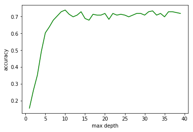

```python
accs = []
for i in range(1, 40):
    tree = DecisionTreeClassifier(max_depth=i)
    tree.fit(mnist, labels)

    prediction = tree.predict(test_data)
    accs.append(metrics.accuracy_score(test_label, prediction))

maximum_depth = accs.index(max(accs))+1
print("MAX: ", max(accs), ", depth: ", maximum_depth)

x = np.array(range(1, 40))
y = np.array(accs)

plt.plot(x, y, color='g')
plt.xlabel('max depth')
plt.ylabel('accuracy')
plt.show()
```

#### ۱۰.visualization

```python
from sklearn.tree import export_graphviz
from IPython.display import SVG
from graphviz import Source
from IPython.display import display

tree = DecisionTreeClassifier(max_depth=maximum_depth)
tree.fit(mnist, labels)

graph = Source(export_graphviz(
    tree,
    out_file=None,
    feature_names=list(mnist.columns),
    class_names=['0', '1', '2', '3', '4', '5', '6', '7', '8', '9'],
    filled=True,
    rounded=True))

display(SVG(graph.pipe(format='svg')))
```

[figure not shown]

#### ۱۱.اورفیت

هرقدر پیچیده تر باشد، یعنی شاخه هایش بیشتر باشد یعنی بیشتر تطبیق پیدا کرده و شانش یادگیری نویز ها بالاست. همچنین کافی نبودن داده ها و زیاد بودن ابعاد داده هم باعث اورفیت می شوند.

### جنگل تصادفی(Random Forest)

#### ۱۲.توضیح الگوریتم

این الگوریتم نمونه های تصادفی را از داده های یادگیری انتخاب می کند و با آن ها یک درخت تصمیم را می سازد. سپس با درخت هایی که ساخته برای هر ورودی پیشبینی را انجام میدهد و بین پیشبینی های درخت ها رای گیری می کند و نتیجه را گزارش می کند.

#### ۱۳.اجرای الگوریتم

```python
from sklearn.ensemble import RandomForestClassifier



mnist = pandas.read_csv("MNIST/train_data.csv")  # numpy of lists
labels = pandas.read_csv("MNIST/train_label.csv")  # numpy of lists


# Defining and fitting a DecisionTreeClassifier instance
tree = RandomForestClassifier()
train_label = labels['0'].to_numpy()
tree.fit(mnist, train_label)

test_data = pandas.read_csv("MNIST/test_data.csv").values
test_label = pandas.read_csv("MNIST/test_label.csv").values

prediction = tree.predict(test_data)
print(classification_report(test_label, prediction))
print("Accuracy of test:", metrics.accuracy_score(test_label, prediction))

train_p = tree.predict(mnist.values)
print("Accuracy of train:", metrics.accuracy_score(labels.values, train_p))
```

```
              precision    recall  f1-score   support

           0       0.94      0.94      0.94        16
           1       0.83      0.96      0.89        25
           2       0.78      0.93      0.85        27
           3       0.79      0.73      0.76        15
           4       0.82      0.74      0.78        19
           5       0.58      0.92      0.71        12
           6       0.89      0.61      0.72        28
           7       0.81      0.81      0.81        21
           8       1.00      0.68      0.81        19
           9       0.63      0.71      0.67        17

    accuracy                           0.80       199
   macro avg       0.81      0.80      0.79       199
weighted avg       0.82      0.80      0.80       199

Accuracy of test: 0.7989949748743719
Accuracy of train: 0.9994997498749375
```

#### ۱۴.tuning

```
MAX:  0.9346733668341709 , depth:  25
```

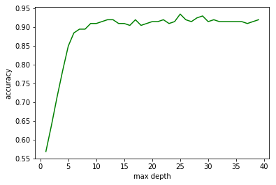

```python
mnist = pandas.read_csv("MNIST/train_data.csv")  # numpy of lists
labels = pandas.read_csv("MNIST/train_label.csv")  # numpy of lists

test_data = pandas.read_csv("MNIST/test_data.csv").values
test_label = pandas.read_csv("MNIST/test_label.csv").values


accs = []
for i in range(1, 40):
    tree = RandomForestClassifier(n_estimators=350,max_depth=i)
    train_label = labels['0'].to_numpy()
    tree.fit(mnist, train_label)

    prediction = tree.predict(test_data)
    accs.append(metrics.accuracy_score(test_label, prediction))

maximum_depth = accs.index(max(accs))+1
print("MAX: ", max(accs), ", depth: ", maximum_depth)

x = np.array(range(1, 40))
y = np.array(accs)

plt.plot(x, y, color='g')
plt.xlabel('max depth')
plt.ylabel('accuracy')
plt.show()
```

#### ۱۵.تغییر پارامترهای دیگر

max_features: حداکثر تعداد فیچرهایی که هنگام شکستن داده ها باید چک کند. min_samples_split: حداقل تعداد سمپل هایی که یک نود باید دارا باشد.

```python
accs = []
for i in range(1,  500):
    tree = RandomForestClassifier(n_estimators=i)
    train_label = labels['0'].to_numpy()
    tree.fit(mnist, train_label)

    prediction = tree.predict(test_data)
    accs.append(metrics.accuracy_score(test_label, prediction))

maximum_depth = accs.index(max(accs))+1
print("MAX: ", max(accs), ", N_EST: ", maximum_depth)

x = np.array(range(1, 500))
y = np.array(accs)

plt.plot(x, y, color='g')
plt.xlabel('n_estimators')
plt.ylabel('accuracy')
plt.show()


accs = []
for i in range(50,  700):
    tree = RandomForestClassifier(min_samples_split=i)
    train_label = labels['0'].to_numpy()
    tree.fit(mnist, train_label)

    prediction = tree.predict(test_data)
    accs.append(metrics.accuracy_score(test_label, prediction))

maximum_depth = accs.index(max(accs))+1
print("MAX: ", max(accs), ", MIN_SPLIT: ", maximum_depth)

x = np.array(range(50, 700))
y = np.array(accs)

plt.plot(x, y, color='m')
plt.xlabel('min_samples_split')
plt.ylabel('accuracy')
plt.show()


accs = []
for i in range(20,  600):
    tree = RandomForestClassifier(max_features=i)
    train_label = labels['0'].to_numpy()
    tree.fit(mnist, train_label)

    prediction = tree.predict(test_data)
    accs.append(metrics.accuracy_score(test_label, prediction))

maximum_depth = accs.index(max(accs))+1
print("MAX: ", max(accs), ", MAX_FEAT: ", maximum_depth)

x = np.array(range(20, 600))
y = np.array(accs)

plt.plot(x, y, color='c')
plt.xlabel('max_features')
plt.ylabel('accuracy')
plt.show()
```

[output not shown]

#### ۱۶.بررسی هم خوانی درخت تصمیم و جنگل تصادفی k=1

```python
mnist = pandas.read_csv("MNIST/train_data.csv")  # numpy of lists
labels = pandas.read_csv("MNIST/train_label.csv")  # numpy of lists


# Defining and fitting a DecisionTreeClassifier instance
tree = RandomForestClassifier(n_estimators=1)
train_label = labels['0'].to_numpy()
tree.fit(mnist, train_label)

test_data = pandas.read_csv("MNIST/test_data.csv").values
test_label = pandas.read_csv("MNIST/test_label.csv").values

prediction = tree.predict(test_data)
print("Accuracy of forest:", metrics.accuracy_score(test_label, prediction))


tree = DecisionTreeClassifier()
tree.fit(mnist, labels)

test_data = pandas.read_csv("MNIST/test_data.csv").values
test_label = pandas.read_csv("MNIST/test_label.csv").values

prediction = tree.predict(test_data)
print("Accuracy of test:", metrics.accuracy_score(test_label, prediction))
```

```
Accuracy of forest: 0.5979899497487438
Accuracy of test: 0.7185929648241206
```

این ادعا درست نیست. چون جنگل تصادفی بطور تصادفی بخشی از نمونه ها را برمی دارد و با آن درخت می سازد درحالیکه درخت تصمیم کارش را با نمونه های کامل آغاز می کند.

### رگرسیون لجستیک

#### ۱۷.توضیح الگوریتم

الگوریتم رگرسیون لاجستیک ابتدا با توجه به داده های یادگیری تابعی بر اساس فیچرها برای هرکلاس بدست می آورد(با روش رگرسیون خطی). برای هر ورودی جدید مقادیر این توابع را حساب می کند و برای هر یک احتمال را جواب بودن را حساب می کند. سپس این احتمالات را تبدیل به فاصله می کند به نحوی که اگر فاصله این ورودی از کلاسی کم باشد، پس احتمالا عضو آن کلاس است.

#### ۱۸.اجرای الگوریتم

```python
from sklearn.linear_model import LogisticRegression



mnist = pandas.read_csv("MNIST/train_data.csv")  # numpy of lists
labels = pandas.read_csv("MNIST/train_label.csv")  # numpy of lists


# Defining and fitting a DecisionTreeClassifier instance
model = LogisticRegression(multi_class='multinomial', solver='newton-cg')
train_label = labels['0'].to_numpy()
model.fit(mnist, train_label)

test_data = pandas.read_csv("MNIST/test_data.csv").values
test_label = pandas.read_csv("MNIST/test_label.csv").values

prediction = model.predict(test_data)
print(classification_report(test_label, prediction))
print("Accuracy of test:", metrics.accuracy_score(test_label, prediction))

train_p = model.predict(mnist.values)
print("Accuracy of train:", metrics.accuracy_score(labels.values, train_p))
```

```
              precision    recall  f1-score   support

           0       0.94      0.94      0.94        16
           1       0.83      1.00      0.91        25
           2       0.80      0.89      0.84        27
           3       0.81      0.87      0.84        15
           4       1.00      0.84      0.91        19
           5       0.69      0.75      0.72        12
           6       1.00      0.86      0.92        28
           7       0.90      0.86      0.88        21
           8       0.82      0.74      0.78        19
           9       0.71      0.71      0.71        17

    accuracy                           0.85       199
   macro avg       0.85      0.84      0.84       199
weighted avg       0.86      0.85      0.85       199

Accuracy of test: 0.8542713567839196
Accuracy of train: 1.0
```

### K-Means

#### ۱۹.توضیح الگوریتم

این الگوریتم به صورت مکرر عملیاتی را انجام می دهد و آن گروه بندی است. در ابتدا به تعداد گروه ها نقاطی تصادفی تولید می کند. سپس هر سمپل را با نقطه ای که به آن از لحاظ فاصله اقلیدسی نزدیک تر است گروه می کند. هربار که سمپلی به گروهی اضافه می شود، مقدار نقطه مرکزی را میانگین نقاط هم گروهی اش قرار می دهد. پس از تکمیل شدن، دوباره نقاط مرکزی را بر می دارد و سمپل ها را با آن ها گروه بندی می کند. این کار انقدر تکرار می شود که مقادیر نقاط مرکزی دیگر تغییر نکنند.

#### ۲۰.یادگیری و رسم مرکزها

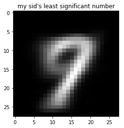

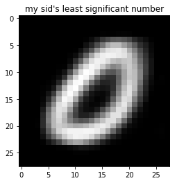

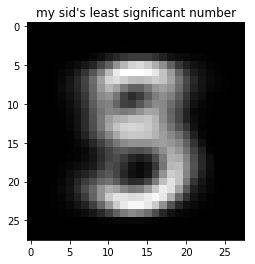

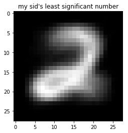

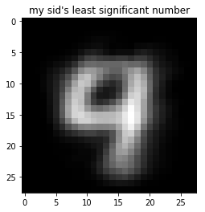

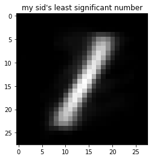

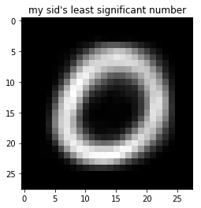

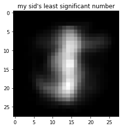

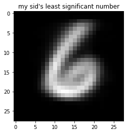

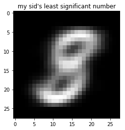

```python
from sklearn.cluster import KMeans
import pandas
from sklearn.decomposition import PCA as sklearnPCA
import matplotlib.pyplot as plt



kmeans = KMeans(n_clusters=10, max_iter=300)

kmeans.fit(mnist)

centroids = kmeans.cluster_centers_

for i in range(0, 10):
        pixels = np.array(centroids[i], dtype='uint8')

        # Reshape the array into 28 x 28 array (2-dimensional array)
        pixels = pixels.reshape((28, 28))

        plt.title('my sid\'s least significant number')
        plt.imshow(pixels, cmap='gray')
        plt.show()
```

#### ۲۱.اجرای الگوریتم

```python
index_labels = [9,0,8,2,4,1,0,5,6,8]
prediction_index = kmeans.predict(data_eval)
prediction = []
for i in prediction_index:
    prediction.append(index_labels[i])
prediction = np.array(prediction)
print(classification_report(label_eval, prediction))
print("Accuracy of test:", metrics.accuracy_score(label_eval, prediction))
```

```
              precision    recall  f1-score   support

           0       0.92      0.69      0.79        16
           1       0.71      0.20      0.31        25
           2       0.88      0.56      0.68        27
           3       0.00      0.00      0.00        15
           4       0.43      0.84      0.57        19
           5       0.12      0.50      0.19        12
           6       0.95      0.64      0.77        28
           7       0.00      0.00      0.00        21
           8       0.36      0.79      0.49        19
           9       0.33      0.29      0.31        17

    accuracy                           0.46       199
   macro avg       0.47      0.45      0.41       199
weighted avg       0.53      0.46      0.44       199

Accuracy of test: 0.457286432160804
```